# Biodiversity across a salinity gradient

# Rarefaction Curves

## `ggiNEXT` Rarefaction Curves

```r
# Prepare Colors
color_df <-
  iNEXT_input_df %>%
  colnames() %>%
  data.frame()
# Check
head(color_df)
```

```
##             .
## 1 SRR12873300
## 2 SRR12873301
## 3 SRR12873302
## 4 SRR12873303
## 5 SRR12873304
## 6 SRR12873305
```

```r
# Rename the column
colnames(color_df)[1] <- "names"
# Check
head(color_df)
```

```
##         names
## 1 SRR12873300
## 2 SRR12873301
## 3 SRR12873302
## 4 SRR12873303
## 5 SRR12873304
## 6 SRR12873305
```

```r
# Make a helper dataframe for plotting with colors
iNEXT_color_df <-
  color_df %>%
  # Merge with metadata
  left_join(metadata_df, by = "names")

head(iNEXT_color_df)
```

```
##         names Assay.Type AvgSpotLen    Bases  BioProject    BioSample
## 1 SRR12873300    RNA-Seq        602 38217368 PRJNA669203 SAMN16456597
## 2 SRR12873301    RNA-Seq        602 27434946 PRJNA669203 SAMN16456596
## 3 SRR12873302    RNA-Seq        602 25072698 PRJNA669203 SAMN16456595
## 4 SRR12873303    RNA-Seq        602 33445916 PRJNA669203 SAMN16456594
## 5 SRR12873304    RNA-Seq        602 31103534 PRJNA669203 SAMN16456593
## 6 SRR12873305    RNA-Seq        602 27821430 PRJNA669203 SAMN16456592
##                BioSampleModel    Bytes                 Center.Name
## 1 Metagenome or environmental 19816770 CHINESE ACADEMY OF SCIENCES
## 2 Metagenome or environmental 14391830 CHINESE ACADEMY OF SCIENCES
## 3 Metagenome or environmental 13473539 CHINESE ACADEMY OF SCIENCES
## 4 Metagenome or environmental 18077252 CHINESE ACADEMY OF SCIENCES
## 5 Metagenome or environmental 16864536 CHINESE ACADEMY OF SCIENCES
## 6 Metagenome or environmental 14779531 CHINESE ACADEMY OF SCIENCES
##   Collection_Date Consent DATASTORE.filetype DATASTORE.provider
```

[output cut: 48 more lines]

```r
# Check how many groups need to be colored
length(unique(iNEXT_color_df$oxygen_level))
```

```
## [1] 5
```

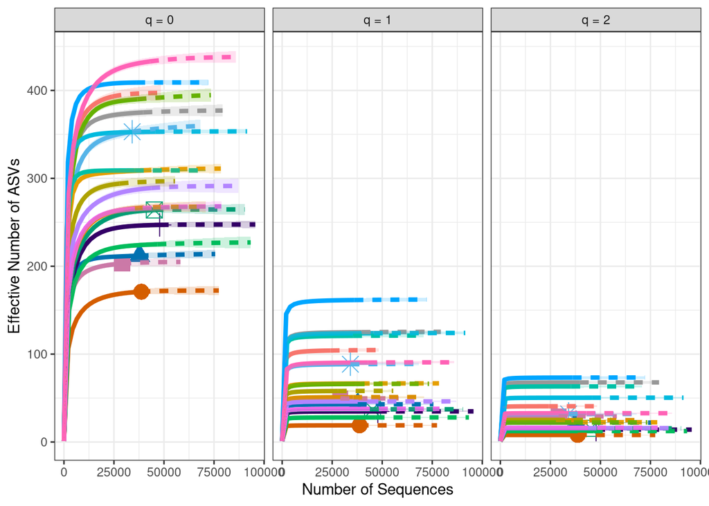

```r
# Plot it
ggiNEXT(iNEXT_data, type = 1, facet.var = "Order.q") +
  theme_bw() +
  theme(legend.position = "none") +
  labs(y = "Effective Number of ASVs", x = "Number of Sequences")
```

## Manual Rarefaction Curves

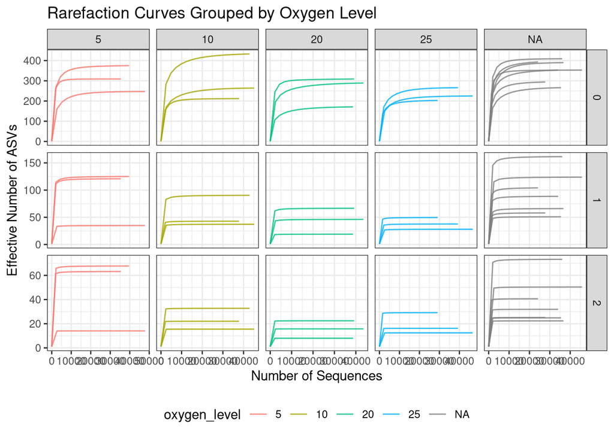

```r
# Build df for manual rarefaction curves
iNEXT_manual_df <- iNEXT_data$iNextEst$size_based %>%
  rename(names = Assemblage) %>%
  left_join(iNEXT_color_df %>% dplyr::select(names, oxygen_level), by = "names")

library(ggplot2)

# Make sure oxygen_level is a factor
iNEXT_manual_df$oxygen_level <- factor(iNEXT_manual_df$oxygen_level)

# Count how many colors are needed
n_oxygen_levels <- length(unique(iNEXT_manual_df$oxygen_level))

# Plot manually
iNEXT_manual_df %>%
  dplyr::filter(Method == "Rarefaction") %>%
  ggplot(aes(x = m, y = qD, color = oxygen_level, group = names)) +
  geom_line(alpha = 0.8) +
  facet_grid(Order.q ~ oxygen_level, scales = "free") +
  scale_color_manual(values = scales::hue_pal()(n_oxygen_levels)) +
  theme_bw() +
  labs(
    y = "Effective Number of ASVs",
    x = "Number of Sequences",
    title = "Rarefaction Curves Grouped by Oxygen Level"
  ) +
  theme(legend.position = "bottom")
```

**INTERPRETATION #1: What can you conclude from the ggiNEXT and manual rarefaction curve plots? Are there “enough” sequences to analyze the samples? Is it valid to make any conclusions about species richness when q = 0? What about when q = 1? Or q = 2? Why or why not?**

The ggiNEXT plot displays rarefaction curves for each individual sample across diversity orders (q = 0, 1, 2). While helpful for showing overall trends, it can be difficult to distinguish sample-specific patterns or how alpha diversity varies by categorical variables like oxygen level.

The faceted rarefaction plot resolves this by grouping samples by oxygen concentration. This allows us to compare how microbial diversity changes with oxygen levels, across orders of diversity (q).

# Statististical Testing

## Parametric vs. Non-Parametric Statistics

```r
distinct_metadata_df <-
  metadata_df
  # There are some redundant samples, let's remove them
  #dplyr::filter(fraction == "Whole")

# Test of the data is normal for the continuous value of salinity
shapiro.test(distinct_metadata_df$oxygen_level)
```

```
##
##  Shapiro-Wilk normality test
##
## data:  distinct_metadata_df$oxygen_level
## W = 0.84051, p-value = 0.02809
```

So, the test above has a p-value < 0.05, indicating that we can reject the H₀, which will indicate that the data is **not normal**. Therefore, we need to use non-parametric statistical tests in the data.

*Is the richness data normal?*

```r
### Now what about for richness?
obs_div_df <-
  iNEXT_manual_df %>%
  dplyr::filter(Method == "Observed")

# check it
glimpse(obs_div_df)
```

```
## Rows: 57
## Columns: 11
## $ names        <chr> "SRR12873300", "SRR12873300", "SRR12873300", "SRR12873301…
## $ m            <dbl> 38696, 38696, 38696, 37790, 37790, 37790, 29101, 29101, 2…
## $ Method       <chr> "Observed", "Observed", "Observed", "Observed", "Observed…
## $ Order.q      <dbl> 0, 1, 2, 0, 1, 2, 0, 1, 2, 0, 1, 2, 0, 1, 2, 0, 1, 2, 0, …
## $ qD           <dbl> 171.000000, 18.951299, 7.998713, 212.000000, 42.846649, 2…
## $ qD.LCL       <dbl> 167.812237, 18.596455, 7.854501, 209.169697, 42.110052, 2…
## $ qD.UCL       <dbl> 174.187763, 19.306142, 8.142926, 214.830303, 43.583245, 2…
## $ SC           <dbl> 0.9998708, 0.9998708, 0.9998708, 0.9999206, 0.9999206, 0.…
## $ SC.LCL       <dbl> 0.9997655, 0.9997655, 0.9997655, 0.9998341, 0.9998341, 0.…
## $ SC.UCL       <dbl> 0.9999761, 0.9999761, 0.9999761, 1.0000000, 1.0000000, 1.…
## $ oxygen_level <fct> 20, 20, 20, 10, 10, 10, 25, 25, 25, 5, 5, 5, 10, 10, 10, …
```

```r
# Pull out unique data from the three fractions of samples
obs_whole_rich_df <-
  obs_div_df %>%
  #dplyr::filter(fraction == "Whole") %>%
  dplyr::filter(Order.q == 0)

# Test of the data is normal for the continuous value of richness
shapiro.test(obs_whole_rich_df$qD)
```

```
##
##  Shapiro-Wilk normality test
##
## data:  obs_whole_rich_df$qD
## W = 0.96775, p-value = 0.7306
```

YES! The diversity data is normal. This means that when we run these tests, we can use parametric tests that assume normality of our data. This makes our statistical testing a lot more robust. Therefore, we can use ANOVA.

## Statistics in Microbial Ecology

# Categorical Analysis: 2 or more groups

# Oxygen level by names

```r
# Run Kruskal-Wallis test for alpha diversity vs oxygen_level
kw_oxygen <- obs_div_df %>%
  kruskal_test(qD ~ oxygen_level)

# Post-hoc test with Dunn's Test
dunn_oxygen <- obs_div_df %>%
  dunn_test(qD ~ oxygen_level, p.adjust.method = "fdr") %>%
  add_xy_position(x = "oxygen_level")

# View results
kw_oxygen
```

```
## # A tibble: 1 × 6
##   .y.       n statistic    df     p method
## * <chr> <int>     <dbl> <int> <dbl> <chr>
## 1 qD       57      1.83     3 0.608 Kruskal-Wallis
```

```r
dunn_oxygen
```

```
## # A tibble: 6 × 13
##   .y.   group1 group2    n1    n2 statistic     p p.adj p.adj.signif y.position
##   <chr> <chr>  <chr>  <int> <int>     <dbl> <dbl> <dbl> <chr>             <dbl>
## 1 qD    5      10         9     9   -0.705  0.481 0.795 ns                 453.
## 2 qD    5      20         9     9   -1.14   0.254 0.762 ns                 477.
## 3 qD    5      25         9     9   -1.20   0.231 0.762 ns                 501.
## 4 qD    10     20         9     9   -0.436  0.663 0.795 ns                 525.
## 5 qD    10     25         9     9   -0.492  0.623 0.795 ns                 549.
## 6 qD    20     25         9     9   -0.0559 0.955 0.955 ns                 573.
## # ℹ 3 more variables: groups <named list>, xmin <dbl>, xmax <dbl>
```

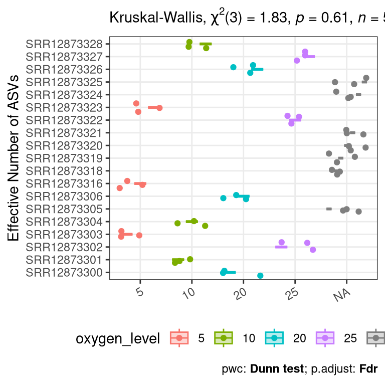

```r
# Oxygen level by qD
oxygen_ggboxplot <-
  ggboxplot(obs_div_df, x = "oxygen_level", y = "names",
          color = "oxygen_level", fill = "oxygen_level", alpha = 0.3,
          outlier.shape = NA) +
  geom_jitter(aes(color = oxygen_level)) +
  labs(y = "Effective Number of ASVs") +
  stat_pvalue_manual(dunn_oxygen, hide.ns = TRUE,
                     tip.length = 0, step.increase = 0.01) +
  labs(subtitle = get_test_label(kw_oxygen, detailed = TRUE),
       caption = get_pwc_label(dunn_oxygen)) +
  theme_bw() +
  theme(legend.position = "bottom",
        axis.title.x = element_blank(),
        axis.text.x = element_text(angle = 30, hjust = 1))

# Show the plot
oxygen_ggboxplot
```

### Diversity by Oxygen level

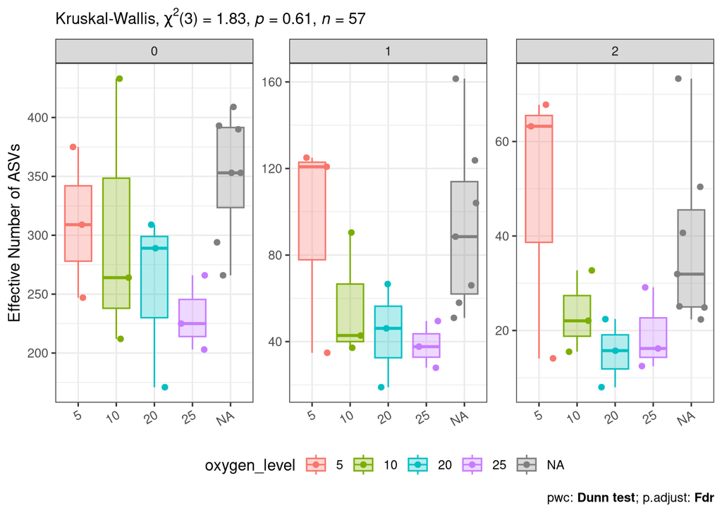

```r
# Plot boxplots by oxygen level against diversity
ggboxplot(obs_div_df, x = "oxygen_level", y = "qD",
          color = "oxygen_level", fill = "oxygen_level", alpha = 0.3,
          outlier.shape = NA) +
  facet_wrap(.~Order.q, scales = "free_y") +
  geom_jitter(aes(color = oxygen_level)) +
  labs(y = "Effective Number of ASVs") +
  stat_pvalue_manual(dunn_oxygen, hide.ns = TRUE,
                     tip.length = 0, step.increase = 0.01) +
  labs(subtitle = get_test_label(kw_oxygen, detailed = TRUE),
       caption = get_pwc_label(dunn_oxygen)) +
  theme_bw() +
  theme(legend.position = "bottom",
        axis.title.x = element_blank(),
        axis.text.x = element_text(angle = 30, hjust = 1, vjust = 1))
```

#### Statistically test Richness

```r
# Filter richness
obs_rich_df <- obs_div_df %>%
  filter(Order.q == 0)
# ANOVA test
anova_oxygen_rich <-
  aov(qD ~ oxygen_level, data = obs_rich_df)

# Look at it
anova_oxygen_rich
```

```
## Call:
##    aov(formula = qD ~ oxygen_level, data = obs_rich_df)
##
## Terms:
##                 oxygen_level Residuals
## Sum of Squares      12862.25  48064.00
## Deg. of Freedom            3         8
##
## Residual standard error: 77.51129
## Estimated effects may be unbalanced
## 7 observations deleted due to missingness
```

```r
summary(anova_oxygen_rich)
```

```
##              Df Sum Sq Mean Sq F value Pr(>F)
## oxygen_level  3  12862    4287   0.714  0.571
## Residuals     8  48064    6008
## 7 observations deleted due to missingness
```

```r
# Richness by oxygen level
rich_ggboxplot <-
  ggboxplot(obs_rich_df, x = "oxygen_level", y = "qD",
          color = "oxygen_level", fill = "oxygen_level", alpha = 0.3,
          outlier.shape = NA) +
  geom_jitter(aes(color = oxygen_level)) +
  labs(y = "# of Total ASVs (Richness)") +
  stat_compare_means(method = "anova", label.y = max(obs_rich_df$qD, na.rm = TRUE)) +
  geom_pwc(aes(group = oxygen_level), tip.length = 0, hide.ns = TRUE,
           method = "t_test", label = "p.adj.format",
           p.adjust.method = "fdr", bracket.nudge.y = -0.08) +
  theme_bw() +
  theme(legend.position = "none",
        axis.title.x = element_blank(),
        axis.text.x = element_text(angle = 30, hjust = 1, vjust = 1))
```

### Simpson

```r
# Pull out simpson data
obs_simps_df <-
  obs_div_df %>%
  filter(Order.q == 2)

# Calculate the ANOVA since the data is normal
anova_oxygen_simps <-
  aov(qD ~ oxygen_level, data = obs_simps_df)

# Look at it
anova_oxygen_simps
```

```
## Call:
##    aov(formula = qD ~ oxygen_level, data = obs_simps_df)
##
## Terms:
##                 oxygen_level Residuals
## Sum of Squares      1989.404  2182.134
## Deg. of Freedom            3         8
##
## Residual standard error: 16.51565
## Estimated effects may be unbalanced
## 7 observations deleted due to missingness
```

```r
summary(anova_oxygen_simps)
```

```
##              Df Sum Sq Mean Sq F value Pr(>F)
## oxygen_level  3   1989   663.1   2.431   0.14
## Residuals     8   2182   272.8
## 7 observations deleted due to missingness
```

[figure not shown]

```r
# Simpson by oxygen level
simps_ggboxplot <-
  ggboxplot(obs_simps_df, x = "oxygen_level", y = "qD",
          color = "oxygen_level", fill = "oxygen_level", alpha = 0.3,
          outlier.shape = NA) +
  geom_jitter(aes(color = oxygen_level)) +
  labs(y = "# of Dominant ASVs (Simpson)") +
  stat_compare_means(method = "anova", label.y = max(obs_simps_df$qD, na.rm = TRUE)) +
  geom_pwc(aes(group = oxygen_level), tip.length = 0, hide.ns = TRUE,
           method = "t_test", label = "p.adj.signif",
           step.increase = 0.08,
           p.adjust.method = "fdr", bracket.nudge.y = -0.08) +
  theme_bw() +
  theme(legend.position = "none",
        axis.title.x = element_blank(),
        axis.text.x = element_text(angle = 30, hjust = 1, vjust = 1))

# Show the plots together
rich_ggboxplot + simps_ggboxplot
```

**INTERPRETATION #2: If you have categorical data, what can you conclude regarding the role that all ASVs (richess, q = 0) versus common ASVs (Shannon, q = 1) versus dominant ASVs (Simpson, q = 2) have on the biodiversity of your samples as it relates to your variable of interest?**

*Shannon Diversity: q = 1* Shannon diversity decreased with oxygen level increase, but more dramatically than richness. This suggests that while more taxa are present at low oxygen, their relative abundances are not evenly distributed.

*Simpson Diversity: q = 2* The less oxygen-rich environments supported not just more ASVs, but also a more balanced community, as indicated by higher Simpson diversity. In contrast, high-oxygen samples were dominated by a few tolerant taxa, lowering q = 2 values.

**INTERPRETATION #3: How did you statistically test your scientific question in Interpretation #2? Why?**

I used Kruskal-Wallis Tests and Post-Hoc Dunn’s Test. Kruskal-Wallis is appropriate for non-normal or heteroscedastic data. It is commonly used in ecological datasets. Dunn’s test pinpoints where the differences lie between group pairs. Dunn’s test pinpoints where the differences lie between group pairs. This approach is robust and interpretable, giving insight into how oxygen levels shift entire community structures, not just mean values.

# Continuous Relationships - Oxygen level vs Biodiversity

## Environmental Variables

There are no environmental variables in the metadata of this research, and the only factor that affect the biodiversity is oxygen level provided into the bioreactor.

## Continuous Variable

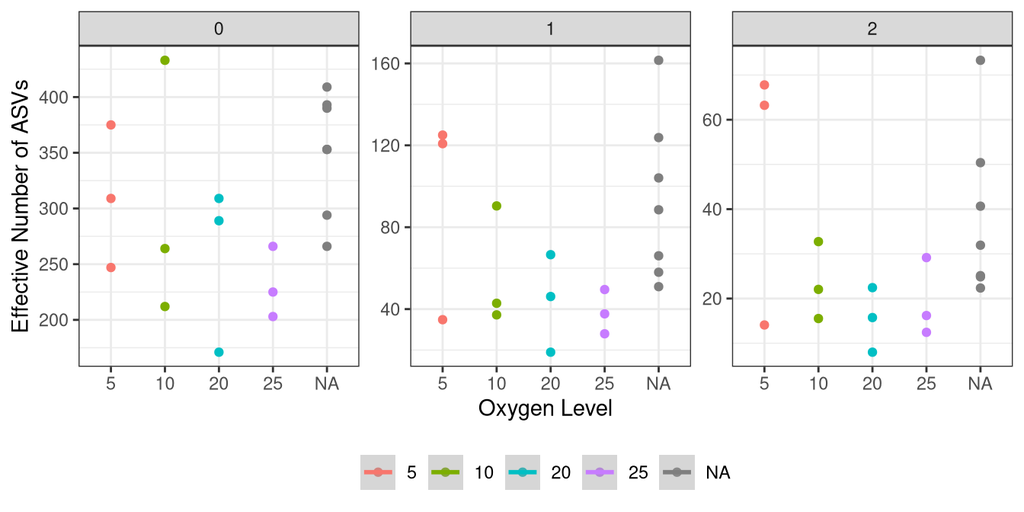

```r
# How does biodiversity change over the oxygen level?
obs_div_df %>%
  ggplot(aes(x = oxygen_level, y = qD, color = oxygen_level)) +
  facet_wrap(.~Order.q, scales = "free") +
  geom_point(aes(color = oxygen_level)) +
  labs(x = "Oxygen Level", y = "Effective Number of ASVs") +
  stat_smooth(method = "lm", formula = y ~poly(x, 2)) +
  theme_bw() +
  theme(legend.position = "bottom",
        legend.title = element_blank())
```

### Explore Richness More

```r
# Make a richness data frame
richness_df <-
  obs_div_df %>%
  dplyr::filter(Method == "Observed") %>%
  dplyr::filter(Order.q == 0)

# Actually run the linear model
rich_vs_oxy_lm <-
  lm(qD ~ oxygen_level, data = richness_df)

# Show me the model results
rich_vs_oxy_lm
```

```
##
## Call:
## lm(formula = qD ~ oxygen_level, data = richness_df)
##
## Coefficients:
##    (Intercept)  oxygen_level10  oxygen_level20  oxygen_level25
##        310.333          -7.333         -54.000         -79.000
```

```r
# Type?
class(rich_vs_oxy_lm)
```

```
## [1] "lm"
```

```r
# Summary of lm
summary(rich_vs_oxy_lm)
```

```
##
## Call:
## lm(formula = qD ~ oxygen_level, data = richness_df)
##
## Residuals:
##     Min      1Q  Median      3Q     Max
## -91.000 -45.083  -3.833  39.167 130.000
##
## Coefficients:
##                Estimate Std. Error t value Pr(>|t|)
## (Intercept)     310.333     44.751   6.935  0.00012 ***
## oxygen_level10   -7.333     63.288  -0.116  0.91061
## oxygen_level20  -54.000     63.288  -0.853  0.41834
## oxygen_level25  -79.000     63.288  -1.248  0.24723
## ---
## Signif. codes:  0 '***' 0.001 '**' 0.01 '*' 0.05 '.' 0.1 ' ' 1
##
## Residual standard error: 77.51 on 8 degrees of freedom
##   (7 observations deleted due to missingness)
## Multiple R-squared:  0.2111, Adjusted R-squared:  -0.08472
## F-statistic: 0.7136 on 3 and 8 DF,  p-value: 0.5709
```

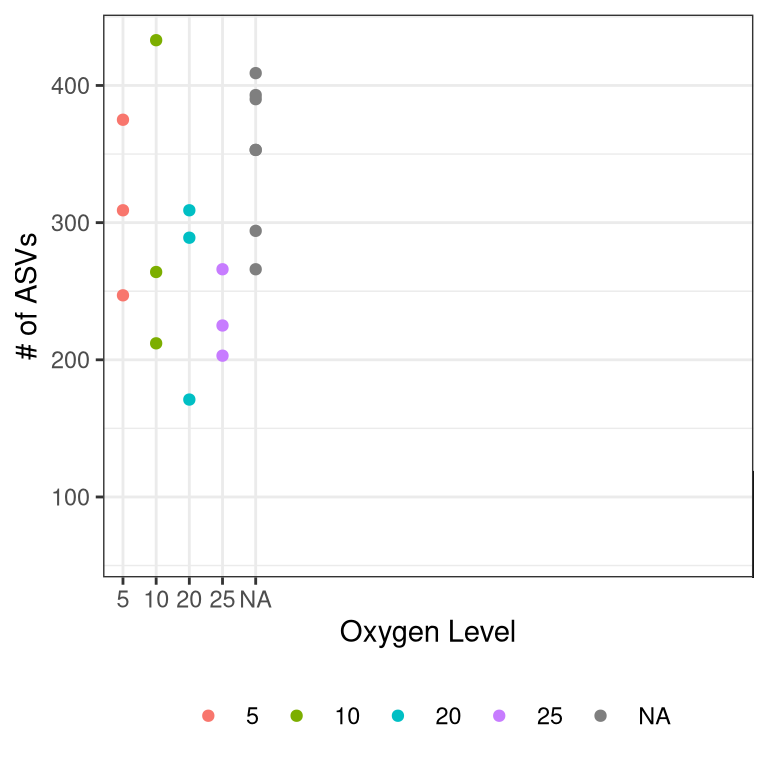

```r
richness_df %>%
  ggplot(aes(x = oxygen_level, y = qD)) +
  geom_point(aes(color = oxygen_level)) +
  stat_smooth(method = "lm") +
  labs(x = "Oxygen Level", y = "# of ASVs") +
  theme_bw() +
  theme(legend.position = "bottom",
        legend.title = element_blank()) +
  geom_label(aes(x = 20, y = 60), hjust = 0,
             label = paste("Adj R2 = ",signif(summary(rich_vs_oxy_lm)$adj.r.squared, 2),
                           "\nIntercept =",signif(rich_vs_oxy_lm$coef[[1]],3),
                           " \nSlope =",signif(rich_vs_oxy_lm$coef[[2]], 2),
                           " \nP =",signif(summary(rich_vs_oxy_lm)$coef[2,4], 2)))
```

## Spearman Correlation

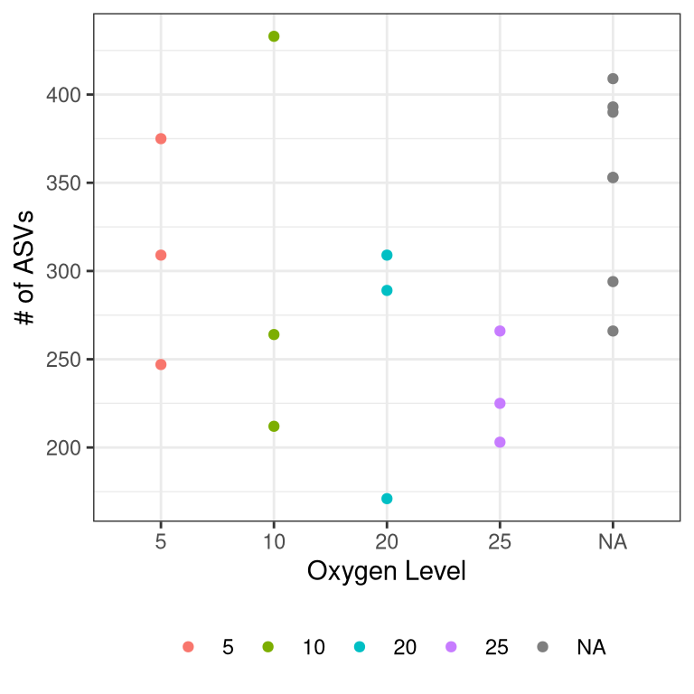

```r
richness_df %>%
  ggplot(aes(x = oxygen_level, y = qD)) +
  geom_point(aes(color = oxygen_level)) +
  stat_smooth(method = "lm") +
  labs(x = "Oxygen Level", y = "# of ASVs") +
  theme_bw() +
  theme(legend.position = "bottom",
        legend.title = element_blank()) +
  stat_cor(method = "spearman", label.x = 3, label.y = 30)  # customize label position
```

**INTERPRETATION #4: If you have continuous data, what can you conclude regarding the role that all ASVs (richess, q = 0) versus common ASVs (Shannon, q = 1) versus dominant ASVs (Simpson, q = 2) have on the biodiversity of your samples as it relates to your variable of interest?**

The trend line cannot be plotted and showed on the plots. But I am still able to observe the general trend based on the points.

*Shannon Diversity: q = 1* A negative trend is observed, suggesting more even communities form as oxygen decrease. The decrease is more linear than for richness.

*Simpson Diversity: q = 1* Dominant ASVs do not vary as strongly with oxygen level beyond 10. This suggests dominant taxa are stable across oxygen gradients, while rare/common ASVs are more oxygen-sensitive.

**INTERPRETATION #5: How did you statistically test your scientific question in Interpretation #4? Why?**

Linear regression is ideal for continuous predictors like oxygen concentration.Polynomial terms are added to model curvature, and it is important in ecological gradients. It provides interpretable effect sizes (slopes) and significance for hypothesis testing. Spearman correlations also have been used for rank-based relationships that don’t assume linearity.

# Final info for Reproducibility

## Check Render Time

```r
# Take the time now that we are at the end of the script
end_time <- Sys.time()
end_time
```

```
## [1] "2025-04-11 12:19:14 EDT"
```

```r
# Echo the elapsed time
elapsed_time <- round((end_time - start_time), 3)
elapsed_time
```

```
## Time difference of 13.111 mins
```